# Structural connectivity of wetlands

[NO_CONN_003]

Authors

Affiliations

Bendik Sivertsen

Sállir Natur AS

Jesus Adrian Chimal-Ballesteros

Sállir Natur AS

Lasse Keetz

Field Geospatial AS

Published

November 24, 2026

**NoteStatus of this document**

This document follows the structure of NINA’s ecRxiv indicator template. It has **not** been submitted to or published on ecRxiv, and it is not a NINA product. The ecRxiv badges and the ecRxiv citation are therefore left out. The ID is the same as that of NINA’s wetland connectivity indicator on ecRxiv (formerly NO_CONN_001). It has been agreed with Miljødirektoratet. This is our own implementation of that indicator.

**TipMetadata**

Table 1: Indicator metadata

| Variable | Value |
| --- | --- |
| Indicator ID | NO_CONN_003 |
| Indicator name | Structural connectivity of wetlands |
| Norwegian name | Konnektivitet i våtmark |
| Continent | Europe |
| Country | Norway |
| Ecosystem Condition Typology class | C1 - Landscape and Seascape characteristics |
| Realm | Freshwater-Terrestrial (TF) |
| Biome | TF1 Palustrine wetlands biome |
| Ecosystem | TF1.6 Boreal, temperate and montane peat bogs; TF1.7 Boreal and temperate fens |
| Norwegian ecosystem | Våtmark |
| Year added | 2026 |
| Last update | 2026 |
| Status | complete |
| Version | 000.001 |
| Version comment | National coverage based on AR5. Our scaling; the original had none |
| Normalised | Yes |
| Spatial aggregation pathway | Transform (log) - Scale - Truncate - Aggregate (area-weighted arithmetic mean) |
| Precision | Standard deviation and 95% interval from 1000 bootstrap samples |

**TipLog**

- 24 Nov. 2026 - First version of this document

## 1. Summary

1. **Background and rationale**: Roads, buildings and other infrastructure break up the landscape between wetlands. The indicator compares how close each mire lies to infrastructure with how close it lies to another mire.
2. **Methods**: For each mire, the distance to the nearest infrastructure is divided by the distance to the nearest other mire. The ratio (Norwegian: *kvotient*) is log-transformed and scaled to 0–1.
   - Mires come from the land-resource map AR5, dissolved into connected patches.
   - Infrastructure is where an index of land-use intensity (Erikstad et al., 2023), built from N50 maps, exceeds 2. It is searched for within 1000 m.
3. **Interpretation**: A value of 1 means no infrastructure within 1000 m, or infrastructure very far away compared with the next mire. Values decreasing towards 0 mean that infrastructure lies closer. At 0, infrastructure touches the mire.
4. **Results and development needs**: The national value is 0.898, with the lowest value in Vestlandet (0.825) and the highest in Østlandet (0.917). 81% of the patches have no infrastructure within 1000 m and score 1 by definition, so the regional value largely reflects the area of such mires. The scaling is ours and needs an expert assessment, and the reference levels must be fixed before the indicator can be used as a time series.

## 2. About the underlying data

- **Wetland**: AR5 *myr* (mire).
- **Infrastructure**: Kartverket’s N50 maps (2023) and NVE’s regulated lakes, combined into the land-use intensity index.
- **Regions**: five regions from NINAnor/ecosystemCondition.

### 2.1 Spatial and temporal resolution and extent

Mainland Norway. The year label 2023 is the N50 edition. The index has also been calculated for 2006 and 2013, but the indicator has not.

### 2.2 Sampling design

No sampling: all mires in AR5 are used.

### 2.3 Original units

Metres for the two distances. The ratio is dimensionless.

### 2.4 Instructions for citing, using and accessing data

N50 and NVE data are open. AR5 requires access through Norge digitalt; without it, the pipeline uses the open AR50. **No geometry derived from AR5 is published**, only regional results. Sources, versions and download dates are listed in the README.

### 2.5 Additional comments about the dataset

NINA’s original used a mire probability model. It stops at about 64° N, so a variant based on it would describe a different population in Nord-Norge than elsewhere. That variant has been calculated and is kept for comparison, see Table 4.

## 3. Indicator properties

### 3.1 Ecosystem Condition Typology Class (ECT)

C1 - landscape and seascape characteristics, as in NINA’s NO_CONN_003.

### 3.2 Ecosystem condition characteristic

Landscape connectivity. In the Norwegian system: *landskapsøkologiske mønstre*.

### 3.3 Collinearities with other indicators

Other indicators built on infrastructure or land use.

### 3.4 Impact factors

Roads, buildings, energy infrastructure and other land use, and loss of mire area.

### 3.5 Spatial aggregation

The ratio is scaled per mire and aggregated as an area-weighted mean of the indicator values, per region and nationally. The reported `v` is the area-weighted geometric mean of the ratios that are finite and above 0.

## 4. Reference condition and levels

### 4.1 Reference condition

Minimal negative human impact on the connectivity between wetlands.

### 4.2 Reference levels

- **X<sub>100</sub>**: the 99th percentile of the log ratio in the run (ratio = 1488).
- **X<sub>0</sub>**: the 1st percentile (ratio = 0.156).
- **Defined values**: no infrastructure within 1000 m gives 1; infrastructure touching the mire gives 0.
- **X<sub>60</sub>**: not defined on the ratio scale. NINA uses 0.6 tentatively; it is also the platform default.

The original left scaling and aggregation unfinished ([issue #144](https://github.com/NINAnor/ecosystemCondition/issues/144)). Its text describes a reference calculated without infrastructure. The scaling here is our own.

#### 4.2.1 Spatial resolution and validity

The same levels apply to the whole country. They are percentiles of this run, so they change if the population or the infrastructure data change, and the two variants are not on the same scale.

## 5. Uncertainties

### 5.1 General uncertainties

- **Scaling.** The percentiles describe the present distribution, not an ecological limit.
- **The 1000 m limit** decides which mires score 1.
- **Infrastructure data.** One category of the index (“other built-up areas”) has no certain N50 object type and is left out, which gives a small undercount.
- **Generalised outlines.** Patches are simplified with a 2 m tolerance; the area is preserved.
- **Touching mires.** 2,341 of 722,567 patches have an infinite ratio because they touch another mire. They are excluded.
- **Region borders.** 234 patches cross a region border and are counted in both regions and twice nationally. Without this, the regional values change by less than 0.0004 and the national value by less than 0.0001.
- **Structure only.** The indicator says nothing about which species move between mires.

### 5.2 Reported uncertainties

`sd` and the 95% interval come from 1000 bootstrap samples of the patches. They are inferential. As all mires are included, they express how much the mean depends on individual patches rather than a sampling error. Uncertainty in the data and in the scaling is not included.

## 6. References

Erikstad, L., Simensen, T., Bakkestuen, V., & Halvorsen, R. (2023). Index measuring land use intensity—A gradient-based approach. *Geomatics, 3*(1), 188–204. https://doi.org/10.3390/geomatics3010010

The method follows NINA’s indicator document NO_CONN_003 by Bakkestuen. The aggregation pathway follows an unpublished manuscript by Kolstad et al. (NINA), which is not included.

## 7. Import and prepare datasets

The code in chapters 7, 9 and 11 is read from the scripts in `R/` when this document is rendered. It is shown, but not executed. The results in chapter 10 are read from the files those scripts wrote to `outputs/`. To recalculate everything, run the scripts in the order given in the README.

A full run takes about 25 hours. Intermediate results are available for download, see the README.

### 7.1 Infrastructure: land-use intensity index

```r
# ============================================================
# NO_CONN_003 - compute the Land Use Intensity (LUI) infrastructure
# index (Erikstad et al. 2023, "Index Measuring Land Use Intensity -
# A Gradient-Based Approach"), from the harmonized BI/LCI/ALI layers
# produced by extract_n50_infrastructure_layers.R.
#
# This is input A of the Connectivity indicator (NO_CONN_003) - the
# original GEE script thresholds this exact index at >2 to build an
# infrastructure mask (`infrastrukturMask = infrastruktur.gt(2)`, see
# NO_CONN_001_wetland_analysis.qmd). Producing that mask/the actual
# connectivity distance calculation is a SEPARATE, later build step -
# this script only produces the LUI raster itself, matching what the
# original GEE asset (`users/vegar/NY_INFRA_IND`) would contain.
#
# ALGORITHM (from the paper, confirmed by direct methodology extraction):
#   1. 100m x 100m national grid.
#   2. For each cell, count how many 100m "presence" cells (grid cells
#      containing at least one relevant feature) fall within a 500m
#      radius circular neighborhood.
#   3. Log-transform each component: component_index = log2(4+X) - 2
#      (constant k=4 chosen so the index climbs 1 unit as counts go
#      0->4->12->28->60).
#   4. Combine: LUI = 2*log2(4+BI) + log2(4+LCI) - 6
#      LUI_ext = 2*log2(4+BI) + log2(4+LCI) - 0.5*log2(4+ALI) - 7
#
# MODELLING CHOICE, documented not hidden: the paper's exact wording for
# step 2 is "only cells with a major fraction of their area situated
# within the circumference of the circle are included" - i.e. an
# area-fraction-weighted circular window. This script instead uses a
# CELL-CENTER-DISTANCE circular kernel (a cell is in the neighborhood if
# its center is within 500m) - the standard definition used by most GIS
# focal-window tools (including terra's own `focalMat(type="circle")`
# at zero threshold) when an exact area-weighted variant isn't
# explicitly requested. The practical difference is confined to the
# handful of boundary cells at the very edge of each 500m circle - not
# expected to materially change results, but flagged here as a real
# simplification, not silently assumed equivalent.
#
# KNOWN INCOMPLETENESS, carried over from the extraction step: LCI is
# missing "other built-up areas" (no confirmed N50 object type, genuinely
# ambiguous even in the source paper's own Table 1). LCI counts here are
# therefore a systematic (if probably minor) undercount relative to the
# original methodology, not a bug.
#
# Output: data/LUI_output/LUI_<year>.tif and LUI_ext_<year>.tif
# (2-component and 3-component-with-ALI versions), plus the
# intermediate BI/LCI/ALI component-index and raw-count rasters for
# diagnostics/transparency, for each of 2006/2013/2023.
# ============================================================

library(terra)
library(sf)

# The full national grid turned out much bigger than first estimated:
# 177,411,306 cells (11906 x 14901), not the ~38.5M guessed from Norway's
# land AREA - the bounding RECTANGLE around Norway's shape (elongated
# SW-NE, lots of the rectangle is Sweden/Finland/ocean with no N50 data
# at all) is ~4.6x larger than the land area alone. A first national run
# crashed silently (no R error text, just stopped mid-rasterize) -
# consistent with an in-memory OOM crash, not a logic error. Forcing all
# raster operations to be disk-backed/chunked fixes this, at some speed
# cost - confirmed necessary at this scale, not a precautionary guess.
terraOptions(memfrac = 0.4, todisk = TRUE)

if (requireNamespace("rstudioapi", quietly = TRUE) && rstudioapi::isAvailable()) {
  setwd(dirname(rstudioapi::getActiveDocumentContext()$path))
} else {
  cmd_args   <- commandArgs(trailingOnly = FALSE)
  file_match <- grep("^--file=", cmd_args)
  tried <- tryCatch({
    if (length(file_match) > 0) {
      setwd(dirname(normalizePath(sub("^--file=", "", cmd_args[file_match]))))
    } else {
      setwd(dirname(sys.frame(1)$ofile))
    }
    TRUE
  }, error = function(e) FALSE)
  if (!tried) message("Note: keeping current working directory (", getwd(), ").")
}

extracted_dir <- file.path("..", "data", "infra_index_source", "N50_extracted")
out_dir       <- file.path("..", "data", "LUI_output")
if (!dir.exists(out_dir)) dir.create(out_dir, recursive = TRUE)

RES        <- 100   # metres, per the paper
RADIUS     <- 500   # metres, per the paper
K          <- 4      # log-transform constant, per the paper

years <- c("2006", "2013", "2023")

# ---------------------------------------------------------------
# Optional AOI restriction for testing - set to NULL for a full
# national run. A small bounding box (e.g. around Oslo) is much faster
# to sanity-check the algorithm's behaviour before committing to the
# full country. Set via environment variable so this script doesn't
# need editing to switch modes:
#   LUI_TEST_AOI=oslo   -> small box around central Oslo
#   LUI_TEST_AOI=""     -> full national run (default if unset)
# ---------------------------------------------------------------
test_aoi <- Sys.getenv("LUI_TEST_AOI", unset = "")
aoi_boxes <- list(
  oslo = ext(258000, 268000, 6642000, 6652000)  # 10km x 10km, central Oslo, EPSG:25833
)

# ---------------------------------------------------------------
# Build a shared national (or AOI-restricted) grid template, aligned to
# clean 100m cell boundaries, from 2023's BI_points extent (most
# complete year, and Norway's land extent doesn't change 2006->2023 at
# a scale that matters here).
# ---------------------------------------------------------------
build_grid_template <- function(res, aoi_name) {
  if (nzchar(aoi_name)) {
    e <- aoi_boxes[[aoi_name]]
    if (is.null(e)) stop("Unknown LUI_TEST_AOI value: ", aoi_name)
  } else {
    ref <- st_read(file.path(extracted_dir, "N50_extracted_2023.gpkg"), layer = "BI_points", quiet = TRUE)
    e <- ext(vect(ref))
    e <- ext(floor(e[1] / res) * res, ceiling(e[2] / res) * res,
             floor(e[3] / res) * res, ceiling(e[4] / res) * res)
  }
  rast(e, resolution = res, crs = "EPSG:25833")
}
grid_template <- build_grid_template(RES, test_aoi)
cat("Grid template:", ncol(grid_template), "x", nrow(grid_template), "cells (",
    ncol(grid_template) * nrow(grid_template), "total )\n")

# ---------------------------------------------------------------
# Circular focal kernel: cell-center distance <= RADIUS (see header
# comment re: this vs. the paper's area-fraction wording).
# ---------------------------------------------------------------
make_circle_kernel <- function(res, radius_m) {
  n <- radius_m %/% res
  size <- 2 * n + 1
  kernel <- matrix(0, size, size)
  center <- n + 1
  for (i in 1:size) for (j in 1:size) {
    d <- sqrt(((i - center) * res)^2 + ((j - center) * res)^2)
    if (d <= radius_m) kernel[i, j] <- 1
  }
  kernel
}
kernel_500m <- make_circle_kernel(RES, RADIUS)
cat("Circular kernel:", sum(kernel_500m), "cells within", RADIUS, "m radius.\n")

# ---------------------------------------------------------------
# Rasterize one or more vector layers (from one gpkg) into a single
# binary presence raster on the shared template. Missing layers are
# skipped (not every geometry-type layer exists for every category/
# year - e.g. no LCI_lines anywhere).
# ---------------------------------------------------------------
rasterize_presence <- function(gpkg_path, layer_names, template) {
  presence <- NULL
  avail <- tryCatch(st_layers(gpkg_path)$name, error = function(e) character(0))
  for (ln in layer_names) {
    if (!ln %in% avail) next
    v <- vect(st_read(gpkg_path, layer = ln, quiet = TRUE))
    if (length(v) == 0) next
    r <- rasterize(v, template, field = 1, background = 0, touches = TRUE)
    presence <- if (is.null(presence)) r else max(presence, r, na.rm = TRUE)
  }
  if (is.null(presence)) {
    presence <- template
    values(presence) <- 0
  }
  presence
}

compute_component_index <- function(presence_raster, kernel) {
  count <- focal(presence_raster, w = kernel, fun = "sum", na.rm = TRUE)
  idx <- log2(K + count) - 2
  list(count = count, index = idx)
}

# NVE regulated lakes - single source, shared across all years (no
# historical archive available/needed - ALI is the extended, lowest-
# weighted part of the index). The extraction script writes it into
# N50_extracted/ alongside the
# per-year files (same out_dir was reused there for all outputs), NOT
# one level up - confirmed by checking that script's own out_path.
nve_path <- file.path(extracted_dir, "NVE_extracted_regulated_lakes.gpkg")
if (!file.exists(nve_path)) nve_path <- NA_character_
cat("NVE regulated-lakes source:", nve_path, "\n")

for (yr in years) {
  cat("\n========== YEAR", yr, "==========\n")
  gpkg <- file.path(extracted_dir, paste0("N50_extracted_", yr, ".gpkg"))
  if (!file.exists(gpkg)) { message("  Missing extracted file for ", yr, ", skipping."); next }

  cat("Rasterizing BI presence...\n")
  bi_presence <- rasterize_presence(gpkg, c("BI_points", "BI_lines", "BI_polygons"), grid_template)

  cat("Rasterizing LCI presence...\n")
  lci_presence <- rasterize_presence(gpkg, c("LCI_points", "LCI_polygons"), grid_template)

  cat("Rasterizing ALI presence (N50 + NVE)...\n")
  ali_n50 <- rasterize_presence(gpkg, c("ALI_lines", "ALI_polygons"), grid_template)
  if (!is.na(nve_path)) {
    ali_nve <- rasterize_presence(nve_path, st_layers(nve_path)$name, grid_template)
  } else {
    ali_nve <- grid_template
    values(ali_nve) <- 0
  }
  ali_presence <- max(ali_n50, ali_nve, na.rm = TRUE)

  cat("Computing focal counts + component indices (this is the slow step)...\n")
  bi  <- compute_component_index(bi_presence, kernel_500m)
  lci <- compute_component_index(lci_presence, kernel_500m)
  ali <- compute_component_index(ali_presence, kernel_500m)

  LUI     <- 2 * bi$index + lci$index - 6
  LUI_ext <- 2 * bi$index + lci$index - 0.5 * ali$index - 7

  writeRaster(LUI,     file.path(out_dir, paste0("LUI_", yr, ".tif")),     overwrite = TRUE)
  writeRaster(LUI_ext, file.path(out_dir, paste0("LUI_ext_", yr, ".tif")), overwrite = TRUE)
  writeRaster(bi$count,  file.path(out_dir, paste0("BI_count_", yr, ".tif")),  overwrite = TRUE)
  writeRaster(lci$count, file.path(out_dir, paste0("LCI_count_", yr, ".tif")), overwrite = TRUE)
  writeRaster(ali$count, file.path(out_dir, paste0("ALI_count_", yr, ".tif")), overwrite = TRUE)

  cat("LUI range:", paste(round(range(values(LUI), na.rm = TRUE), 2), collapse = " to "), "\n")
  cat("LUI_ext range:", paste(round(range(values(LUI_ext), na.rm = TRUE), 2), collapse = " to "), "\n")
  cat("Written to", out_dir, "\n")
}

cat("\n\n================================================\n")
cat("LUI COMPUTATION COMPLETE.\n")
cat("Test-mode AOI:", if (nzchar(test_aoi)) test_aoi else "(none - full national run)", "\n")
cat("Remember: LCI is missing 'other built-up areas' (unresolved even at\n")
cat("the source) - a documented, systematic minor undercount, not a bug.\n")
cat("Next step (not done here): threshold LUI > 2 to build the infrastructure\n")
cat("mask and run the actual polygon-distance connectivity calculation.\n")
cat("================================================\n")
```

### 7.2 Mire patches from AR5

```r
# ============================================================
# NO_CONN_003 - build the per-region wetland inputs for the
# certified connectivity pipeline from AR5 myr (ARTYPE 60) instead of the
# mire probability map.
#
# WHY: the mire probability map stops at ~64 N (Nord-Norge falls back to
# NiN-mapped mires only, 4,917 polygons). AR5 myr is national and is the
# wetland population NO_GJEN_001 already uses.
#
# WHAT: for each region, polygons intersecting the region + 10 km buffer
# (the same buffer the model-based inputs carry; the infra step filters
# back to the true boundary), DISSOLVED into connected patches. AR5 splits
# one bog into many adjacent polygons along attribute boundaries; without
# dissolving, every shared edge would give min_myr_distance = 0 and
# kvotient = Inf. The raster-based inputs were connected components
# (terra::patches) - this is the vector equivalent. Then exploded to
# single-part POLYGONs, lightly simplified (2 m tolerance, topology
# preserved) to keep the exact-distance fallback fast, and written in the
# schema run_region_certified.R expects (patch_id, source, mire_id).
#
# Output: data/wetland_map_ar5/wetland_simplified_<Region>.gpkg
# Run the pipeline on it with
#   CONNECTIVITY_MIRE_DIR=../data/wetland_map_ar5
#   CONNECTIVITY_OUT_DIR=../data/connectivity_output_ar5
# (see run_connectivity_ar5.ps1).
# ============================================================
suppressPackageStartupMessages({ library(sf); library(dplyr) })

if (requireNamespace("rstudioapi", quietly = TRUE) && rstudioapi::isAvailable()) {
  setwd(dirname(rstudioapi::getActiveDocumentContext()$path))
} else {
  cmd_args <- commandArgs(trailingOnly = FALSE); fm <- grep("^--file=", cmd_args)
  if (length(fm)) setwd(dirname(normalizePath(sub("^--file=", "", cmd_args[fm]))))
}
sf_use_s2(FALSE)

# Source of the wetland population, in order of preference:
#   1. $AR5_MYR_GPKG, if set
#   2. this indicator's own data/wetland_population/
#   3. the sibling NO_GJEN_001/data/OpenS_data/ copies - the monorepo
#      already has the scripts that build these, so there is no reason to
#      keep a second 2.4 GB copy here
# AR5 (FKB-AR5) is preferred for its finer boundaries, but its licence
# restricts downloading to Norge digitalt parties, so the open AR50
# (NIBIO, NLOD) is used automatically when AR5 is absent. AR50 is national
# too, just coarser. Which one was used is recorded in the `source` column
# of every output, and in the console.
find_population <- function() {
  env <- Sys.getenv("AR5_MYR_GPKG", unset = "")
  if (nzchar(env)) {
    if (!file.exists(env)) stop("AR5_MYR_GPKG is set to a file that does not exist: ", env)
    return(env)
  }
  here <- file.path("..", "data", "wetland_population")
  sib  <- file.path("..", "..", "NO_GJEN_001", "data", "OpenS_data")
  for (d in c(here, sib)) {
    f <- file.path(d, "ar5_myr_national.gpkg")
    if (file.exists(f)) return(f)
  }
  for (d in c(here, sib)) {
    f <- file.path(d, "ar50_myr_national.gpkg")
    if (file.exists(f)) {
      message("AR5 not found - falling back to AR50 (NIBIO, open data, NLOD). ",
              "Coarser boundaries; results will differ slightly - see README.")
      return(f)
    }
  }
  stop("No wetland population layer found.\n",
       "  Looked in: ", here, " and ", sib, "\n",
       "  AR5 (preferred, Norge digitalt parties only): run\n",
       "    NO_GJEN_001/R/extract_ar5_skog_myr.R   -> ar5_myr_national.gpkg\n",
       "  AR50 (open data, NLOD, no access needed): run\n",
       "    NO_GJEN_001/R/build_ar50_wetland_lidar_coverage.R -> ar50_myr_national.gpkg\n",
       "  or set AR5_MYR_GPKG to either file. See this indicator's README.")
}
ar5_path   <- find_population()
pop_source <- if (grepl("ar50", basename(ar5_path))) "ar50_myr" else "ar5_myr"
cat("Wetland population:", ar5_path, "(source tag:", pop_source, ")\n")
# Write where the downstream scripts read from, so one variable defines the
# variant's input folder end to end (run_connectivity_ar5.ps1 sets it).
out_dir  <- Sys.getenv("CONNECTIVITY_MIRE_DIR", unset = file.path("..", "data", "wetland_map_ar5"))
dir.create(out_dir, showWarnings = FALSE, recursive = TRUE)
REGION_BUFFER_M <- 10000
SIMPLIFY_M      <- 2

regions_sel <- strsplit(Sys.getenv("CONNECTIVITY_REGIONS", "Nord-Norge,Sorlandet,Vestlandet,Midt-Norge,Ostlandet"), ",")[[1]]
name_map <- c("Nord-Norge" = "Nord-Norge", "Midt-Norge" = "Midt-Norge", "Vestlandet" = "Vestlandet",
              "Ostlandet" = "Østlandet", "Østlandet" = "Østlandet", "Sorlandet" = "Sørlandet", "Sørlandet" = "Sørlandet")
offset <- c("Nord-Norge" = 1e6, "Midt-Norge" = 2e6, "Østlandet" = 3e6, "Vestlandet" = 4e6, "Sørlandet" = 5e6)

regions <- st_read(file.path("..", "data", "spatial", "regions.shp"), quiet = TRUE)
regions$region[regions$id == 3] <- "Østlandet"; regions$region[regions$id == 5] <- "Sørlandet"

layer <- st_layers(ar5_path)$name[1]
cat("Layer:", layer, "\n")

for (rsel in regions_sel) {
  region_name <- name_map[[rsel]]
  out_path <- file.path(out_dir, paste0("wetland_simplified_", region_name, ".gpkg"))
  if (file.exists(out_path)) { cat("==", region_name, "already prepared - skipping\n"); next }
  t0 <- Sys.time()
  reg_buf <- regions %>% filter(region == region_name) %>% st_buffer(REGION_BUFFER_M) %>% st_union()
  bb <- st_bbox(reg_buf)
  cat("==", region_name, "- reading", pop_source, "within the buffered bbox...\n")
  wkt <- st_as_text(st_as_sfc(bb))
  myr <- st_read(ar5_path, layer = layer, wkt_filter = wkt, quiet = TRUE)
  myr <- myr[lengths(st_intersects(myr, reg_buf)) > 0, ]
  cat("   ", nrow(myr), "source polygons in region + buffer; dissolving touching polygons into patches...\n")
  myr <- st_make_valid(myr)
  patches <- st_union(st_geometry(myr)) %>% st_cast("POLYGON")
  cat("   ", length(patches), "patches after dissolve (", round(as.numeric(difftime(Sys.time(), t0, units = "mins")), 1), "min )\n")
  patches <- st_simplify(patches, preserveTopology = TRUE, dTolerance = SIMPLIFY_M)
  patches <- patches[!st_is_empty(patches)]
  patches <- st_make_valid(patches)
  # st_make_valid can return multiparts/collections - keep polygon parts only, single-part
  patches <- st_collection_extract(patches, "POLYGON") %>% st_cast("POLYGON")
  out <- st_sf(patch_id = offset[[region_name]] + seq_along(patches),
               source   = pop_source,
               mire_id  = seq_along(patches),
               geom     = patches)
  st_write(out, out_path, quiet = TRUE, append = FALSE)
  cat("   written", nrow(out), "single-part patches ->", out_path,
      "(", round(as.numeric(difftime(Sys.time(), t0, units = "mins")), 1), "min total )\n")
  rm(myr, patches, out); gc()
}
cat("Done.\n")
```

## 8. Spatial units

The basic spatial unit (BSU) is the connected mire patch. The values should be interpreted for regions and nationally (ecosystem accounting areas, EAA). Patches within 10 km outside a region are used when distances are calculated, but not in its value.

## 9. Analyses

### 9.1 Distance to the nearest mire

A fast pre-filter finds candidates, and a certification step guarantees that the nearest one is among them.

```r
# ============================================================
# NO_CONN_003 - CERTIFIED nearest-neighbour distance via centroid
# pre-filter + provably-correct fallback for the small minority of rows
# where the pre-filter can't be trusted.
#
# BACKGROUND: nn_distance_centroid_prefilter() (pure centroid k-NN) was
# validated against exact ground truth twice - Femundsmarka (sparse test
# AOI, converged to 0 mismatches by k=50) and a real 20km Sørlandet
# window at true regional density (~6,350 polygons - NOT converging to
# zero even at k=600: still 0.276% mismatched, with individual errors up
# to tens of thousands of metres for elongated/irregular polygon shapes).
# A second real bug (unrelated MULTIPOLYGON mis-grouping from
# terra::patches() under chunked processing, since fixed at the source
# - the simplified per-region caches this reads no longer have it)
# explained PART of this, but a genuine residual approximation-error
# rate remained after that fix too.
# Given this pipeline's own documentation already flags that precision
# matters most exactly where min_myr_distance is small (near-touching
# polygons), an uncertified ~1% error rate isn't acceptable - this
# function makes the result exact everywhere, not just "usually right."
#
# CERTIFICATION, not just a heuristic threshold: for polygon i, let
#   r_k        = centroid distance to the k-th (furthest checked) candidate
#   approx_i   = true min boundary distance among the k checked candidates
#   R_i        = polygon i's own "reach" (max distance from ITS centroid
#                to any of its own vertices)
#   R_max      = the largest such reach among all UNCHECKED candidates
# By the triangle inequality, for ANY unchecked candidate j: boundary_
# distance(i,j) >= centroid_distance(i,j) - R_i - R_j >= r_k - R_i -
# R_max. So if r_k - R_i - R_max >= approx_i, no unchecked candidate can
# possibly beat approx_i - PROVEN, not just probably right. Rows that
# don't meet this bound fall back to a certified growing-buffer exact
# search (nn_distance_exact_for_subset(), below).
#
# GIANT-OUTLIER SEPARATION (added 2026-08-14, after a 43-hour real-world
# incident): a first full-Sørlandet attempt used a single GLOBAL R_max
# across all 374,397 polygons. Checked directly (2026-08-14): full-scale
# max reach is 5,056m - far worse than the 2,376m a smaller 6,351-polygon
# test window suggested - because the true worst-case outlier polygons
# aren't evenly distributed and a small window can easily miss them. That
# run only certified 25.2% of rows at k=600 (vs. 99.7% predicted from the
# small window), pushing 280,118 rows into the slow per-row fallback -
# which then ran 43+ hours with no progress signal before being killed.
# FIX: separate out the rare large-reach "giant" polygons (R > 500m -
# checked directly: only 837 of 374,397, 0.22%) from the general
# population. Giants are ALWAYS included as forced candidates for EVERY
# row (cheap - 837 extra exact-distance checks per row, a bounded, known
# cost), so the general certification bound only needs to defend against
# unchecked NON-giant candidates, whose reach is bounded by R_max_typical
# (499m at this threshold) instead of the punishing global 5,056m. This
# is what makes high certification rates achievable at full national
# scale, not just on a small test window.
# ============================================================

library(sf)
library(dplyr)

if (!requireNamespace("RANN", quietly = TRUE)) stop("RANN package required")

#' Max distance from each polygon's own centroid to any of its own
#' vertices ("reach" R_i in the header comment).
polygon_reach <- function(x) {
  centroids <- st_centroid(st_geometry(x))
  cc <- st_coordinates(centroids)
  vapply(seq_len(nrow(x)), function(i) {
    vc <- st_coordinates(x[i, ])[, 1:2, drop = FALSE]
    max(sqrt((vc[, 1] - cc[i, 1])^2 + (vc[, 2] - cc[i, 2])^2))
  }, numeric(1))
}

#' Exact nearest-OTHER-polygon distance for a subset of rows (by index)
#' within the full set `x`, via a certified growing-buffer search:
#' buffer by r, find candidates via the spatial index (st_intersects,
#' fast), take exact min distance among them; if that min is <= r, it's
#' certified correct (nothing outside the buffer could be closer);
#' otherwise grow r and retry. Now with real progress logging (added
#' 2026-08-14 - the previous version's total silence during a 43-hour
#' real run made it impossible to tell whether it was almost done or
#' barely started; never again).
nn_distance_exact_for_subset <- function(x, idx, initial_r = 300, growth = 4,
                                          max_r = 200000, verbose = TRUE) {
  out <- numeric(length(idx))
  t0 <- Sys.time()
  log_every <- max(1L, round(length(idx) / 200))
  for (ii in seq_along(idx)) {
    i <- idx[ii]
    r <- initial_r
    repeat {
      buf <- st_buffer(x[i, ], r)
      hits <- st_intersects(buf, x, sparse = TRUE)[[1]]
      hits <- hits[hits != i]
      if (length(hits) > 0) {
        dmin <- min(as.numeric(st_distance(x[i, ], x[hits, ])))
        if (dmin <= r) { out[ii] <- dmin; break }
      }
      if (r >= max_r) {
        dall <- as.numeric(st_distance(x[i, ], x[-i, ]))
        out[ii] <- min(dall)
        break
      }
      r <- r * growth
    }
    if (verbose && (ii %% log_every == 0 || ii == length(idx))) {
      elapsed <- as.numeric(difftime(Sys.time(), t0, units = "secs"))
      eta <- elapsed / ii * (length(idx) - ii)
      cat("    fallback row", ii, "/", length(idx), "- [timing]", round(elapsed, 1),
          "sec elapsed, ETA", round(eta / 60, 1), "min\n")
    }
  }
  out
}

#' Certified nearest-OTHER-polygon distance for every row in `x`. Exact
#' for every row, not approximate - see header for the proof sketch.
#'
#' @param x sf polygon object
#' @param k number of centroid-nearest candidates to check per polygon
#'   before falling back to exact search, IN ADDITION to the always-
#'   checked giant set (see giant_threshold_m below). DEFAULT 75 -
#'   re-validated 2026-08-14 after adding giant separation: k=75 alone
#'   (no longer needing k=600) now certifies 99.5% of rows on the real
#'   Sørlandet-density test window (vs. ~2% before giant separation),
#'   with 0 mismatches against exact ground truth - giants, not k, were
#'   always the real lever.
#' @param giant_threshold_m polygons with reach above this are treated
#'   as "giants" - always checked as a forced candidate for every row,
#'   and excluded from the R_max used in the general certification bound.
#'   500m default, chosen from the real full-scale Sørlandet reach
#'   distribution (2026-08-14): only 0.22% of polygons exceed it, and
#'   excluding them drops the effective bound from 5,056m to 499m.
nn_distance_certified <- function(x, k = 75, verbose = TRUE, batch_size = 8000,
                                   giant_threshold_m = 500) {
  n <- nrow(x)
  if (n < 2) stop("Need at least 2 polygons.")
  k <- min(k, n - 1)

  centroids <- st_centroid(st_geometry(x))
  coords <- st_coordinates(centroids)
  nn <- RANN::nn2(data = coords, query = coords, k = k + 1)
  cand_idx  <- nn$nn.idx
  cand_dist <- nn$nn.dists  # ascending per row; column 1 is self (dist 0)

  if (verbose) cat("  Computing per-polygon reach bounds...\n")
  R <- polygon_reach(x)
  giant_idx <- which(R > giant_threshold_m)
  R_max_typical <- if (length(giant_idx) < n) max(R[-giant_idx]) else max(R)
  if (verbose) {
    cat("  Giant polygons (reach >", giant_threshold_m, "m):", length(giant_idx),
        "of", n, "(", round(100 * length(giant_idx) / n, 3), "% ) - always checked directly.\n")
    cat("  R_max_typical (excl. giants):", round(R_max_typical), "m",
        "(vs. global max", round(max(R)), "m)\n")
  }
  n_giants <- length(giant_idx)

  # BATCHED pre-filter distance pass: k-nearest-by-centroid candidates
  # PLUS every giant polygon (forced), processed in fixed-size row
  # batches with an explicit gc() each batch - a real memory leak was
  # found and fixed here 2026-08-12 (large temporary sf subset objects
  # weren't being reclaimed promptly by R's GC in a tight loop; without
  # batching+gc(), RSS grew past 14GB on a full-region run).
  n_batches <- ceiling(n / batch_size)
  approx_dist <- numeric(n)
  t_batch0 <- Sys.time()
  for (b in seq_len(n_batches)) {
    rows_b <- ((b - 1) * batch_size + 1):min(b * batch_size, n)

    # k-NEAREST candidates: flattened by_element pairs (as before) - these
    # are distinct candidates per row, no duplication concern.
    cand_b <- cand_idx[rows_b, , drop = FALSE]
    i_vec <- rep(rows_b, times = k + 1)
    j_vec <- as.vector(cand_b)
    keep  <- i_vec != j_vec
    i_vec <- i_vec[keep]; j_vec <- j_vec[keep]
    d <- as.numeric(st_distance(x[i_vec, ], x[j_vec, ], by_element = TRUE))
    batch_min <- as.numeric(tapply(d, i_vec, min)[as.character(rows_b)])
    rm(i_vec, j_vec, keep, cand_b, d)

    # GIANTS: a real crash was found and fixed here (2026-08-14) - the
    # original version added giants to the SAME flattened by_element pair
    # list, which means each giant polygon's full (large, complex)
    # geometry gets duplicated once per query row in the batch (up to
    # 8,000x) before st_distance() ever runs - giants are by definition
    # the most vertex-heavy polygons, so this duplication blew memory out
    # (std::bad_alloc) on the very first batch of a full-region run, even
    # though the raw PAIR COUNT looked modest. Fixed by computing giant
    # distances as a proper x-by-y CROSS-DISTANCE MATRIX instead
    # (st_distance(rows, giants), no by_element) - GEOS iterates the
    # cross-product internally without any R-level geometry duplication.
    if (n_giants > 0) {
      gmat <- st_distance(x[rows_b, ], x[giant_idx, ])
      gmat <- matrix(as.numeric(gmat), nrow = length(rows_b))
      # self-exclusion: if a row in this batch IS itself a giant, blank
      # out its own self-distance (0) before taking the row minimum.
      self_pos <- match(rows_b, giant_idx)
      has_self <- !is.na(self_pos)
      if (any(has_self)) gmat[cbind(which(has_self), self_pos[has_self])] <- Inf
      giant_min <- apply(gmat, 1, min)
      batch_min <- pmin(batch_min, giant_min)
      rm(gmat, giant_min)
    }

    approx_dist[rows_b] <- batch_min
    rm(batch_min)
    gc(verbose = FALSE)

    if (verbose) {
      elapsed <- as.numeric(difftime(Sys.time(), t_batch0, units = "secs"))
      eta <- elapsed / b * (n_batches - b)
      mem_mb <- round(sum(gc()[, 2]))
      cat("  batch", b, "/", n_batches, "- [timing]", round(elapsed, 1),
          "sec elapsed, ETA", round(eta / 60, 1), "min, mem", mem_mb, "MB\n")
    }
  }

  r_k <- cand_dist[, k + 1]  # furthest KNN-checked centroid distance, per row
  # Giants are always checked directly regardless of r_k, so the bound
  # only needs to defend against unchecked NON-giant candidates - hence
  # R_max_typical, not the punishing global max.
  certified_ok <- (r_k - R - R_max_typical) >= approx_dist
  flagged <- which(!certified_ok)

  if (verbose) {
    cat("  Pre-filter (k=", k, " + ", n_giants, " giants): ", n - length(flagged), " of ", n,
        " rows certified correct (", round(100 * (n - length(flagged)) / n, 2),
        "% ), ", length(flagged), " flagged for exact fallback.\n", sep = "")
  }

  if (length(flagged) > 0) {
    t0 <- Sys.time()
    exact_vals <- nn_distance_exact_for_subset(x, flagged, verbose = verbose)
    approx_dist[flagged] <- exact_vals
    if (verbose) cat("  [timing] exact fallback for", length(flagged), "rows:",
                      round(as.numeric(difftime(Sys.time(), t0, units = "secs")), 1), "sec\n")
  }

  approx_dist
}
```

### 9.2 Distance to infrastructure, and the ratio

```r
# ============================================================
# NO_CONN_003 - compute min_infra_distance + kvotient for one region,
# using the already-computed certified min_myr_distance results
# (data/connectivity_output_simplified/<region>_min_myr_distance_
# certified.gpkg) instead of re-deriving mire polygons from scratch.
#
# This step was NEVER the bottleneck in the whole min_myr_distance saga
# - kept as close to the original methodology as possible: crop LUI to
# the buffered region extent, resample to 10m to match the mire
# raster's own resolution, threshold, vectorize (dissolved), then
# buffer+distance against the certified mire polygons. Tested first on
# the smallest region before committing to full national scale, since
# raster resampling at national extent has been a real source of
# surprises elsewhere in this pipeline (LUI's own 177M-cell grid needed
# disk-backed processing for the same reason - see compute_lui_
# infrastructure_index.R).
#
# After computing kvotient, filters to the TRUE (unbuffered) region
# boundary - the certified min_myr_distance files still contain the full
# 10km-buffered extent (simplify_wetland_polygons.R never filtered this
# out), so combining regions without this filter would double-count
# polygons in the shared buffer zones between adjacent regions.
# ============================================================

library(terra)
library(sf)
library(dplyr)

terraOptions(memfrac = 0.4, todisk = TRUE)

if (requireNamespace("rstudioapi", quietly = TRUE) && rstudioapi::isAvailable()) {
  setwd(dirname(rstudioapi::getActiveDocumentContext()$path))
} else {
  cmd_args   <- commandArgs(trailingOnly = FALSE)
  file_match <- grep("^--file=", cmd_args)
  tried <- tryCatch({
    if (length(file_match) > 0) {
      setwd(dirname(normalizePath(sub("^--file=", "", cmd_args[file_match]))))
    } else {
      setwd(dirname(sys.frame(1)$ofile))
    }
    TRUE
  }, error = function(e) FALSE)
  if (!tried) message("Note: keeping current working directory (", getwd(), ").")
}

region_name <- Sys.getenv("CONNECTIVITY_REGION", unset = "")
# ASCII aliases, so callers (PowerShell, schedulers) never have to pass the
# Norwegian letters - a .ps1 read as ANSI mangles them silently.
if (region_name == "Sorlandet") region_name <- "Sørlandet"
if (region_name == "Ostlandet") region_name <- "Østlandet"
if (!nzchar(region_name)) stop("Set CONNECTIVITY_REGION to one of: Nord-Norge, Midt-Norge, Vestlandet, Østlandet, Sørlandet")

ascii_name <- c(
  "Nord-Norge" = "nord_norge",
  "Midt-Norge" = "midt_norge",
  "Vestlandet" = "vestlandet",
  "Østlandet"  = "ostlandet",
  "Sørlandet"  = "sorlandet"
)[[region_name]]

INFRA_THRESHOLD <- 2
INFRA_BUFFER_M  <- 1000
REGION_BUFFER_M <- 10000
YEAR <- Sys.getenv("CONNECTIVITY_YEAR", unset = "2023")

lui_path <- file.path("..", "data", "LUI_output", paste0("LUI_", YEAR, ".tif"))
conn_dir <- Sys.getenv("CONNECTIVITY_OUT_DIR", unset = file.path("..", "data", "connectivity_output_simplified"))
mire_path <- file.path(conn_dir,
                        paste0(ascii_name, "_min_myr_distance_certified.gpkg"))

cat("Region:", region_name, "- year:", YEAR, "\n")
cat("Loading certified mire polygons (includes 10km buffer zone)...\n")
mire_polygons <- st_read(mire_path, quiet = TRUE)
cat("  ", nrow(mire_polygons), "polygons loaded.\n")

regions_all <- st_read(file.path("..", "data", "spatial", "regions.shp"), quiet = TRUE)
regionlvl <- c("Nord-Norge", "Midt-Norge", "Vestlandet", "Østlandet", "Sørlandet")
regions_all$region[regions_all$id == 3] <- "Østlandet"
regions_all$region[regions_all$id == 5] <- "Sørlandet"
regions_all <- regions_all %>% mutate(region = factor(region, levels = regionlvl)) %>% st_transform(25833)
region_true_boundary <- regions_all %>% filter(region == region_name)
region_buffered_poly <- st_buffer(region_true_boundary, REGION_BUFFER_M)
bb <- st_bbox(region_buffered_poly)
target_extent <- ext(bb["xmin"], bb["xmax"], bb["ymin"], bb["ymax"])
cat("Buffered extent:", as.vector(target_extent), "\n")

# 10m template raster over the buffered extent, matching the mire
# raster's own resolution (no wetland_r available here since we're
# working from already-vectorized polygons, not deriving fresh).
wetland_r_template <- rast(target_extent, resolution = 10, crs = "EPSG:25833")
cat("Template raster cells:", ncell(wetland_r_template), "\n")

cat("Loading infrastructure index, cropping, resampling to 10m...\n")
t0 <- Sys.time()
lui_r <- rast(lui_path)
lui_r <- crop(lui_r, target_extent)
lui_r <- resample(lui_r, wetland_r_template, method = "near")
cat("  [timing] crop+resample:", round(as.numeric(difftime(Sys.time(), t0, units = "secs")), 1), "sec\n")

t0 <- Sys.time()
infra_binary <- lui_r > INFRA_THRESHOLD
infra_binary[infra_binary == 0] <- NA
infra_polygons <- as.polygons(infra_binary, dissolve = TRUE) |> st_as_sf()
cat("  [timing] threshold+vectorize:", round(as.numeric(difftime(Sys.time(), t0, units = "secs")), 1), "sec\n")
cat("Infrastructure polygon(s) (dissolved):", nrow(infra_polygons), "\n")

cat("Computing nearest-infrastructure distances (", INFRA_BUFFER_M, "m local search)...\n")
t0 <- Sys.time()
mire_buffered <- st_buffer(mire_polygons, INFRA_BUFFER_M)
has_nearby_infra <- lengths(st_intersects(mire_buffered, infra_polygons)) > 0

mire_polygons$min_infra_distance <- NA_real_
if (any(has_nearby_infra)) {
  d <- st_distance(mire_polygons[has_nearby_infra, ], infra_polygons)
  mire_polygons$min_infra_distance[has_nearby_infra] <- apply(d, 1, min)
}
cat("  [timing] nearest-infra distance:", round(as.numeric(difftime(Sys.time(), t0, units = "secs")), 1), "sec\n")
cat("  with infrastructure within", INFRA_BUFFER_M, "m:", sum(has_nearby_infra),
    "(", round(100 * mean(has_nearby_infra), 1), "% )\n")

mire_polygons$kvotient <- mire_polygons$min_infra_distance / mire_polygons$min_myr_distance_certified

n_before <- nrow(mire_polygons)
centroids <- st_centroid(st_geometry(mire_polygons))
in_true_region <- lengths(st_intersects(centroids, region_true_boundary)) > 0
mire_polygons <- mire_polygons[in_true_region, ]
cat("True-boundary filter: kept", nrow(mire_polygons), "of", n_before, "polygons.\n")

out_dir <- conn_dir
out_path <- file.path(out_dir, paste0(ascii_name, "_connectivity_full_", YEAR, ".gpkg"))
st_write(mire_polygons, out_path, quiet = TRUE, append = FALSE)

cat("\n=== Summary for", region_name, "===\n")
cat("Final polygon count:", nrow(mire_polygons), "\n")
cat("min_infra_distance (NA = none within buffer): "); print(summary(mire_polygons$min_infra_distance))
cat("kvotient: "); print(summary(mire_polygons$kvotient))
cat("Written to", out_path, "\n")
```

### 9.3 Scaling and aggregation

```r
# ============================================================
# NO_CONN_003 - turn the per-polygon `kvotient` (from R/
# compute_infra_distance_region.R's per-region output) into a 0-1 scaled
# indicator and a standardized regional "Tilstand" map, matching
# NO_GJEN_001/NO_FUNC_003's established map style.
#
# WHY A SEPARATE SCRIPT: the source qmd never actually defined a scaling
# function for connectivity (GitHub issue #144, "scaling and regional
# aggregation" explicitly marked unfinished) - the only hint anywhere is
# a "tentative 0.6 threshold" borrowed from a different indicator. This
# script is therefore OUR reconstruction, not confirmed NINA methodology
# - built following the framework in Kolstad et al. (in prep, "On the
# spatial aggregation of condition metrics for ecosystem accounting" -
# NINA's own guidance on exactly this problem; the manuscript itself is
# not included in this migration copy, see README), not invented from
# scratch.
#
# DATA-INFORMED DESIGN (checked the real kvotient distribution before
# designing this - heavily right-skewed raw, close to symmetric on the
# log scale, consistent with other log-transformed ratio/count
# variables in this project):
#   - THREE special cases handled distinctly, not one blended scale
#     (Kolstad's "natural zero" reference-level concept - some reference
#     levels are defined, not derived from data):
#       kvotient = Inf  -> EXCLUDED (dissolve/topology artifact from
#                           touching mire polygons, not an ecological
#                           signal)
#       kvotient = NA   -> index = 1 (no infrastructure within 1000m =
#                           reference condition, a defined anchor)
#       kvotient = 0    -> index = 0 (infrastructure touches the mire =
#                           complete disruption, a defined anchor)
#       finite, >0      -> log-transform, then scale/truncate between
#                           percentile-based anchors COMPUTED FROM
#                           WHATEVER DATA IS PASSED IN, not hardcoded -
#                           see PERCENTILE_LOWER/UPPER below.
#
# AGGREGATION PATHWAY (Kolstad et al., Table 4, "Pathway 1"): normalise
# EACH mire polygon FIRST, then spatially aggregate (area-weighted mean)
# to the 5 regions - the SAME pathway GJEN_001/FUNC_003 use (Kolstad's
# Recommendation #3: consistent pathway across indicators in the same
# assessment, not a free choice).
#
# ANCHOR STABILITY: anchors are always recomputed fresh from whatever
# data is fed in, never hardcoded - originally a real caution (the first
# test run had only 402 points from 2 small, biased AOIs, not enough to
# trust). The first real national run (2026-08-19) reached n=97,072,
# comfortably past ANCHOR_STABLE_MIN_N below, so this is no longer a
# live concern at national scale - but the adaptive design stays either
# way: the script always prints which anchors it used and whether it
# considers them stable, never silently ambiguous.
#
# SIGMOID TRANSFORM DROPPED (2026-08-19): the finite/nonzero branch
# originally applied GJEN_001's own sigmoid shape on top of the
# truncated linear scale, purely for cross-indicator visual consistency
# - not because CON_001's own ecology needs a threshold/diminishing-
# returns curve. Once real national data existed, plotting the
# sigmoid's actual effect showed a substantial, largely arbitrary
# UPWARD bias (median 0.651 -> 0.824, share >=0.9 from 7.9% to 35.7%)
# simply because most real values happen to fall where the curve sits
# above the identity line - not an ecological design choice. Kolstad's
# Recommendation #3 is about the AGGREGATION PATHWAY, not the per-unit
# curve shape, so dropping the sigmoid doesn't violate it. `index` for
# the finite/nonzero branch is now just the truncated linear-scaled
# log-kvotient value directly.
# ============================================================

library(sf)
library(dplyr)
library(ggplot2)
library(RColorBrewer)
library(ggrepel)

if (requireNamespace("rstudioapi", quietly = TRUE) && rstudioapi::isAvailable()) {
  setwd(dirname(rstudioapi::getActiveDocumentContext()$path))
} else {
  cmd_args   <- commandArgs(trailingOnly = FALSE)
  file_match <- grep("^--file=", cmd_args)
  tried <- tryCatch({
    if (length(file_match) > 0) {
      setwd(dirname(normalizePath(sub("^--file=", "", cmd_args[file_match]))))
    } else {
      setwd(dirname(sys.frame(1)$ofile))
    }
    TRUE
  }, error = function(e) FALSE)
  if (!tried) message("Note: keeping current working directory (", getwd(), ").")
}

connectivity_dir <- Sys.getenv("CONNECTIVITY_SCORE_DIR",
                                unset = file.path("..", "data", "connectivity_output"))
spatial_dir      <- file.path("..", "data", "spatial")
img_dir          <- file.path("..", "outputs", "results")
if (!dir.exists(img_dir)) dir.create(img_dir, recursive = TRUE)

# Which connectivity output file(s) to score - override via env var to
# point at a regional/national run once one exists. Defaults to
# combining every *_TEST.gpkg currently in the output folder (the two
# small AOIs) purely so this script's MECHANISM can be verified - not a
# claim that the resulting map is a real indicator value yet.
# 2026-08-19: first REAL national run - CONNECTIVITY_SCORE_DIR points at
# data/connectivity_output_simplified (the certified-algorithm outputs,
# min_myr_distance_certified column instead of min_myr_distance) and
# CONNECTIVITY_SCORE_PATTERN matches the 5 per-region
# "<region>_connectivity_full_2023.gpkg" files - not the earlier
# *_min_myr_distance_certified.gpkg files (myr-distance only, no kvotient
# yet) also present in that folder.
input_pattern <- Sys.getenv("CONNECTIVITY_SCORE_PATTERN", unset = "connectivity_.*\\.gpkg$")

PERCENTILE_LOWER <- 0.01
PERCENTILE_UPPER <- 0.99

# ---------------------------------------------------------------
# Load and combine input mire polygons (with kvotient) from whichever
# connectivity_output file(s) match the pattern.
# ---------------------------------------------------------------
input_files <- list.files(connectivity_dir, pattern = input_pattern, full.names = TRUE)
if (length(input_files) == 0) stop("No connectivity output files found matching '", input_pattern, "' in ", connectivity_dir)
cat("Scoring", length(input_files), "input file(s):\n"); print(basename(input_files))
```

```r
mire_polygons <- do.call(rbind, lapply(input_files, function(f) {
  x <- st_read(f, quiet = TRUE)
  x$source_file <- basename(f)
  x
}))
cat("Total mire polygons loaded:", nrow(mire_polygons), "\n")

# ---------------------------------------------------------------
# Scaling function - see header for the full rationale.
# ---------------------------------------------------------------
scale_connectivity <- function(x, lower_pct = PERCENTILE_LOWER, upper_pct = PERCENTILE_UPPER) {
  x$index <- NA_real_
  x$index_note <- NA_character_

  is_inf <- is.infinite(x$kvotient)
  x$index_note[is_inf] <- "excluded_topology_artifact"

  is_na_k <- is.na(x$kvotient)
  x$index[is_na_k] <- 1
  x$index_note[is_na_k] <- "reference_no_infra_within_1000m"

  is_zero <- !is.na(x$kvotient) & x$kvotient == 0
  x$index[is_zero] <- 0
  x$index_note[is_zero] <- "extreme_infra_touches_mire"

  is_finite_nonzero <- is.finite(x$kvotient) & x$kvotient > 0
  n_fn <- sum(is_finite_nonzero)
  if (n_fn >= 10) {
    log_k <- log(x$kvotient[is_finite_nonzero])
    X0_log   <- as.numeric(quantile(log_k, lower_pct, na.rm = TRUE))
    X100_log <- as.numeric(quantile(log_k, upper_pct, na.rm = TRUE))
    cat("Anchors computed from THIS run's data (n =", n_fn, "finite nonzero kvotient values):\n")
    cat("  X0 (log scale,", lower_pct * 100, "th pct):", round(X0_log, 3), " -> kvotient =", round(exp(X0_log), 4), "\n")
    cat("  X100 (log scale,", upper_pct * 100, "th pct):", round(X100_log, 3), " -> kvotient =", round(exp(X100_log), 4), "\n")

    scaled <- (log_k - X0_log) / (X100_log - X0_log)
    scaled[scaled < 0] <- 0
    scaled[scaled > 1] <- 1
    # Sigmoid transform DROPPED (2026-08-19, see header) - index is now
    # just the truncated linear-scaled log-kvotient value directly, no
    # further curve applied. GJEN_001's sigmoid shape was borrowed for
    # cross-indicator visual consistency only, not derived from this
    # indicator's own ecology, and was shown to introduce a substantial,
    # largely arbitrary upward bias on the real data (see this script's
    # header for the exact before/after numbers).
    x$index[is_finite_nonzero] <- scaled
    x$index_note[is_finite_nonzero] <- "log_kvotient_linear_scaled_truncated"
  } else {
    message("Fewer than 10 finite nonzero kvotient values (", n_fn, ") - too few to compute ",
            "stable percentile anchors. Those rows left unscored (index = NA).")
  }

  attr(x, "anchors") <- if (n_fn >= 10) c(X0_log = X0_log, X100_log = X100_log) else NULL
  x
}

mire_scored <- scale_connectivity(mire_polygons)

cat("\n=== Scoring summary ===\n")
print(table(mire_scored$index_note, useNA = "ifany"))
cat("\nindex summary (excludes topology-artifact rows):\n")
print(summary(mire_scored$index))

# ---------------------------------------------------------------
# Regional aggregation - same pathway as GJEN_001 (normalise per-polygon
# FIRST, spatially aggregate SECOND), same 5 regions, same Norwegian
# region labels/o-a-encoding fix.
# ---------------------------------------------------------------
regionlvl <- c("Nord-Norge", "Midt-Norge", "Vestlandet", "Østlandet", "Sørlandet")
regions_path <- file.path(spatial_dir, "regions.shp")
regions <- st_read(regions_path, quiet = TRUE)
regions$region[regions$id == 3] <- "Østlandet"
regions$region[regions$id == 5] <- "Sørlandet"
regions <- regions %>% mutate(region = factor(region, levels = regionlvl))

mire_valid <- mire_scored %>%
  filter(!is.na(index)) %>%
  st_transform(st_crs(regions))
# st_area() called on the whole sf object, not a literal "geometry"
# column name - GPKG's default geometry column name is "geom", not
# "geometry" (confirmed the hard way: st_area(geometry) failed with
# "object 'geometry' not found" on data read back from a GPKG).
mire_valid$area <- as.numeric(st_area(mire_valid))

region_agg <- regions %>%
  st_join(mire_valid) %>%
  st_drop_geometry() %>%
  filter(!is.na(index)) %>%
  group_by(region) %>%
  summarise(index = weighted.mean(index, w = area, na.rm = TRUE), n = n(), .groups = "drop")

# ---------------------------------------------------------------
# Bootstrap CI on the regional area-weighted mean (2026-08-19, user
# request). CON_001 was the only one of the three wetland indicators
# with NO uncertainty quantification at the regional aggregation step -
# GJEN_001's ecTools::ea_spread() has a bootstrapped SE built in,
# FUNC_003 has its own boot_median_ci(). Kolstad et al. explicitly
# endorse non-parametric bootstrapping for exactly this ("...can be used
# to possibly obtain better descriptions of the uncertainty in the
# estimates"). Resamples (index, area) PAIRS together (not index alone)
# so each resampled weighted mean reflects genuine sampling uncertainty
# in the actual polygon population, not an unweighted resample.
# ---------------------------------------------------------------
BOOT_N     <- 1000
BOOT_PROBS <- c(0.025, 0.975)
set.seed(1)  # reproducible bootstrap draws, matching FUNC_003's convention

boot_weighted_mean_ci <- function(index, area, n = BOOT_N, probs = BOOT_PROBS) {
  ok <- !is.na(index) & !is.na(area)
  index <- index[ok]; area <- area[ok]
  if (length(index) == 0) return(c(NA_real_, NA_real_))
  if (length(index) == 1) return(c(index, index))
  n_obs <- length(index)
  boot_means <- vapply(seq_len(n), function(i) {
    idx <- sample.int(n_obs, n_obs, replace = TRUE)
    weighted.mean(index[idx], w = area[idx])
  }, numeric(1))
  as.numeric(quantile(boot_means, probs, na.rm = TRUE))
}

cat("\nComputing bootstrap CIs on the regional area-weighted mean (", BOOT_N, "resamples per region)...\n")
t_boot <- Sys.time()
joined_for_boot <- st_drop_geometry(st_join(regions, mire_valid))
joined_for_boot <- joined_for_boot[!is.na(joined_for_boot$index), ]
boot_rows <- lapply(regionlvl, function(r) {
  sub <- joined_for_boot[joined_for_boot$region == r, ]
  if (nrow(sub) == 0) return(data.frame(region = r, boot_low = NA_real_, boot_high = NA_real_))
  ci <- boot_weighted_mean_ci(sub$index, sub$area)
  data.frame(region = r, boot_low = ci[1], boot_high = ci[2])
})
boot_cis <- do.call(rbind, boot_rows)
cat("  [timing]", round(as.numeric(difftime(Sys.time(), t_boot, units = "secs")), 1), "sec\n")
```

```r
region_agg <- region_agg %>% left_join(boot_cis, by = "region")

cat("\n=== Regional aggregation ===\n")
# print(region_agg) would use tibble/pillar's pretty-printer, which loads
# utf8.dll - found blocked by a Windows Application Control policy on
# this machine (2026-08-19), crashing the script AFTER all the real work
# was already done. print.data.frame() avoids that dependency entirely.
print(as.data.frame(region_agg))

# ---------------------------------------------------------------
# Standardized 5-class "Tilstand" map - breaks/labels/colors copied
# directly from NO_GJEN_001_wetland_pipeline_OpenSource.R's own
# condition_map code, so every indicator's regional map reads the same
# way (Kolstad Recommendation #3).
# ---------------------------------------------------------------
condition_breaks <- c(0, 0.2, 0.4, 0.6, 0.8, 1)
condition_labels <- c("Svært dårlig", "Dårlig", "Moderat", "God", "Svært god")
condition_colors <- setNames(
  c("#d7191c", "#fdae61", "#ffffbf", "#a6d96a", "#1a9641"),
  condition_labels
)

# Clip to Norway's real coastline (fjords/islands) for display only - matches
# NO_FUNC_003's map style (st_intersection(reg, nor), the only one of the 3
# wetland indicators that did this). GJEN_001/CON_001 previously drew
# regions.shp raw, giving a visibly smoother/more generalized coastline than
# FUNC_003's map - purely a rendering difference, not a data/value one (see
# 2026-08-20 investigation). Done here, AFTER region_agg is already computed
# from the unclipped `regions`, so this can't perturb the aggregation itself -
# it only affects what geometry the final map draws.
outline_path <- file.path(spatial_dir, "outlineOfNorway_EPSG25833.shp")
nor <- st_read(outline_path, quiet = TRUE) %>% st_transform(st_crs(regions))
regions_clipped <- st_intersection(regions, nor)

condition_map_dat <- regions_clipped %>%
  left_join(region_agg, by = "region") %>%
  mutate(condition = cut(index, breaks = condition_breaks,
                          labels = condition_labels, include.lowest = TRUE))

# Label text got longer once the bootstrap CI was added (2026-08-19) -
# the single-line "%.3f [%.3f-%.3f] (n=%d)" format was wide enough to
# make adjacent regions' label boxes overlap and clip text (seen
# directly on the rendered map). Splitting across 3 lines + shrinking
# font size reduced but did not eliminate the overlap for the
# Vestlandet/Østlandet pair specifically (their point-on-surface
# centroids sit close together along their shared border). Switched to
# ggrepel::geom_label_repel(), which auto-nudges colliding labels apart
# and draws a leader line back to the true point - a permanent fix
# instead of continuing to shrink text.
label_pts <- condition_map_dat %>%
  st_point_on_surface() %>%
  mutate(label = ifelse(
    is.na(index),
    paste0(region, "\nIngen data"),
    sprintf("%s\n%.3f\n[%.3f-%.3f] (n=%d)", region, index, boot_low, boot_high, n)
  ))
label_xy <- st_coordinates(label_pts)
label_pts$x <- label_xy[, "X"]
label_pts$y <- label_xy[, "Y"]

dummy_xy <- st_coordinates(st_point_on_surface(condition_map_dat[1, ]))
legend_dummy <- data.frame(
  condition = factor(condition_labels, levels = condition_labels),
  x = dummy_xy[1, "X"], y = dummy_xy[1, "Y"]
)

# PROVISIONAL vs FINAL labeling is DATA-DRIVEN, not hardcoded - never
# silently assume which mode we're in. The original two-small-test-AOI
# run (402 usable points combined) was explicitly judged NOT
# representative enough for real anchors; the first real national run
# (2026-08-19) used n=97,072 finite-nonzero kvotient values, 241x more.
# ANCHOR_STABLE_MIN_N=5000 is a deliberately conservative line between
# "small test AOI" and "real regional/national scale" - comfortably above
# the rejected 402-point case, comfortably below any real regional run.
ANCHOR_STABLE_MIN_N <- 5000
anchor_info <- attr(mire_scored, "anchors")
n_scored <- sum(mire_scored$index_note == "log_kvotient_linear_scaled_truncated", na.rm = TRUE)
is_final <- !is.null(anchor_info) && n_scored >= ANCHOR_STABLE_MIN_N

map_title <- if (is_final) "NO_CONN_003 indikator Konnektivitet" else "NO_CONN_003 indikator Konnektivitet (PROVISORISK)"

caption_txt <- if (is.null(anchor_info)) {
  "Areal-vektet gjennomsnittlig indeksverdi per region. God tilstand >= 0.6.\nPROVISORISK: for lite data til å beregne anchors."
} else if (is_final) {
  # Not "PROVISORISK" anymore (n is now large/national), but the scaling
  # FUNCTION itself is still our own reconstruction, not confirmed NINA
  # methodology (NINA's own scaling/aggregation step was never finished
  # at the source - GitHub issue #144) - that fact doesn't change just
  # because the anchors are now stable, so it stays noted, just without
  # the data-instability alarm.
  sprintf("Areal-vektet gjennomsnittlig indeksverdi per region. God tilstand >= 0.6.\nAnchors fra n=%d landsdekkende data (X0/X100 log-kvotient = %.2f/%.2f).\nSkaleringsmetodikk uavhengig utviklet (ikke fullført av NINA ved kilden, se issue #144).",
          n_scored, anchor_info["X0_log"], anchor_info["X100_log"])
} else {
  sprintf("Areal-vektet gjennomsnittlig indeksverdi per region. God tilstand >= 0.6.\nPROVISORISK: anchors beregnet fra n=%d denne kjøringen (X0/X100 log-kvotient = %.2f/%.2f) - IKKE offisiell NINA-metodikk.",
          n_scored, anchor_info["X0_log"], anchor_info["X100_log"])
}

connectivity_condition_map <- ggplot() +
  geom_sf(data = condition_map_dat, aes(fill = condition), color = "black", linewidth = 0.4,
          show.legend = FALSE) +
  geom_point(data = legend_dummy, aes(x = x, y = y, fill = condition),
             shape = 22, size = 6, color = "black", alpha = 0) +
  geom_label_repel(data = label_pts, aes(x = x, y = y, label = label),
                    size = 2.6, lineheight = 0.85, fill = "white", color = "black",
                    label.size = 0.3, label.padding = unit(0.2, "lines"),
                    seed = 1, max.overlaps = Inf, min.segment.length = 0,
                    segment.color = "grey40", box.padding = 0.3) +
  scale_fill_manual(
    values = condition_colors, name = "Tilstand", limits = condition_labels,
    drop = FALSE, na.value = "grey80",
    guide = guide_legend(override.aes = list(alpha = 1))
  ) +
  labs(
    title   = map_title,
    caption = caption_txt
  ) +
  theme_void() +
  theme(plot.title = element_text(size = 12, face = "bold"),
        plot.caption = element_text(size = 8, hjust = 0))
```

```r
map_label <- Sys.getenv("CONNECTIVITY_SCORE_LABEL", unset = "national_2023")
map_sfx   <- if (map_label == "national_2023") "" else paste0("_", map_label)   # a variant never overwrites the main map
out_map_path <- file.path(img_dir, if (is_final) paste0("NO_CONN_003_connectivity_condition_map", map_sfx, ".png")
                                   else paste0("NO_CONN_003_connectivity_condition_map_PROVISIONAL", map_sfx, ".png"))
ggsave(out_map_path, connectivity_condition_map, width = 8, height = 8, dpi = 300, bg = "white")

cat("\nMap written to", out_map_path, "\n")
cat("\n================================================\n")
if (is_final) {
  cat("Anchors computed from n =", n_scored, "real data points (>= ", ANCHOR_STABLE_MIN_N,
      "threshold) - labeled FINAL, not provisional.\n")
} else {
  cat("REMINDER: anchors computed from only n =", n_scored, "points (<", ANCHOR_STABLE_MIN_N,
      "threshold) - too few to trust as stable. Re-run against a larger/regional/national\n")
  cat("dataset before treating this as final.\n")
}
cat("This map's underlying SCALING FUNCTION is OUR reconstruction either way,\n")
cat("not confirmed NINA methodology (never finished at the source - issue #144).\n")
cat("================================================\n")


# ===========================================================
# WRITE-OUT (no computation happens here). data/connectivity_scored/
# (gitignored - 450 MB, regenerated by this script in minutes):
#   mire_scored_<label>.gpkg      every mire polygon with kvotient, index, index_note
#   region_agg_<label>.csv        region area-weighted mean index, n, bootstrap CI
#   anchors_<label>.csv           the percentile anchors this run used
# <label> = CONNECTIVITY_SCORE_LABEL env var (default "national_2023").
# R/export_deliverables.R reads these.
# ===========================================================
score_label <- Sys.getenv("CONNECTIVITY_SCORE_LABEL", unset = "national_2023")
scored_dir  <- file.path("..", "data", "connectivity_scored")
if (!dir.exists(scored_dir)) dir.create(scored_dir, recursive = TRUE)

st_write(mire_scored, file.path(scored_dir, paste0("mire_scored_", score_label, ".gpkg")),
         delete_dsn = TRUE, quiet = TRUE)
write.csv(as.data.frame(region_agg), file.path(scored_dir, paste0("region_agg_", score_label, ".csv")), row.names = FALSE)
anch <- attr(mire_scored, "anchors")
write.csv(data.frame(X0_log = anch[["X0_log"]], X100_log = anch[["X100_log"]],
                     X0_kvotient = exp(anch[["X0_log"]]), X100_kvotient = exp(anch[["X100_log"]]),
                     percentile_lower = PERCENTILE_LOWER, percentile_upper = PERCENTILE_UPPER,
                     n_scored = n_scored, is_final = is_final),
          file.path(scored_dir, paste0("anchors_", score_label, ".csv")), row.names = FALSE)
cat("\nWrite-out:", nrow(mire_scored), "scored polygons ->", scored_dir, "(label", score_label, ")\n")
```

## 10. Results

Table 2: Indicator values (AR5). v is the geometric mean ratio; the interval is the 95% bootstrap interval

| Region | n | v | Indicator | 95% interval |
| --- | --- | --- | --- | --- |
| Norge | 720,460 | 41.3 | 0.898 | 0.893–0.902 |
| Nord-Norge | 127,464 | 31.3 | 0.855 | 0.837–0.872 |
| Midt-Norge | 186,159 | 57.3 | 0.911 | 0.905–0.918 |
| Vestlandet | 78,023 | 28.4 | 0.825 | 0.818–0.831 |
| Østlandet | 203,211 | 43.4 | 0.917 | 0.911–0.922 |
| Sørlandet | 125,603 | 26.8 | 0.908 | 0.879–0.923 |

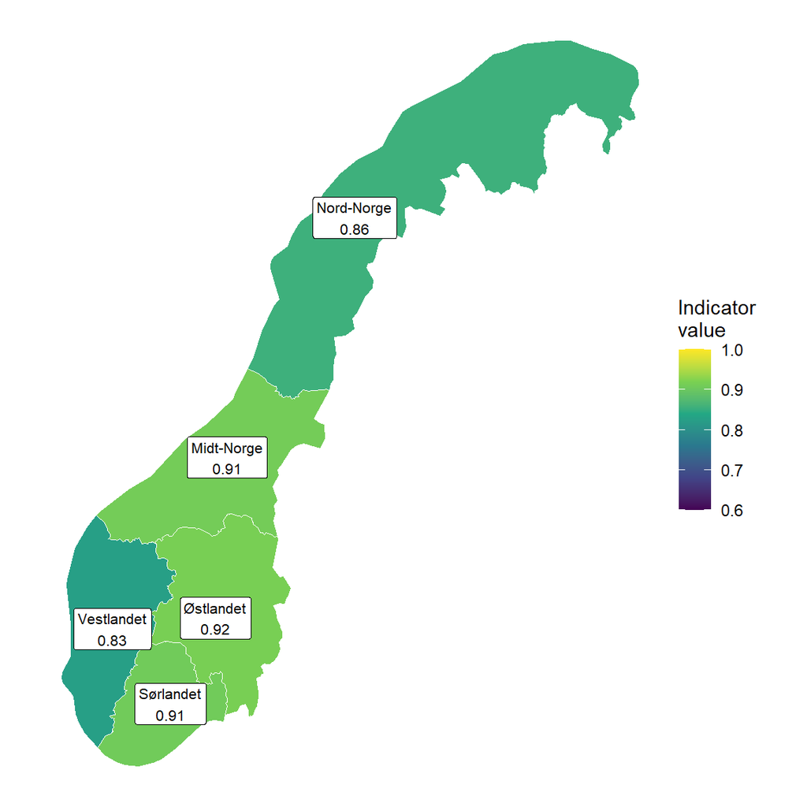

Figure 1: Indicator values per region (AR5)

Table 3: How the patches are scored: number of patches and share per region

| Region | No infrastructure within 1000 m (1) | Scaled ratio | Touched by infrastructure (0) |
| --- | --- | --- | --- |
| Norge | 583,934 (81%) | 111,403 (15%) | 25,123 (3%) |
| Nord-Norge | 102,302 (80%) | 20,064 (16%) | 5,098 (4%) |
| Midt-Norge | 154,372 (83%) | 26,735 (14%) | 5,052 (3%) |
| Vestlandet | 52,970 (68%) | 19,530 (25%) | 5,523 (7%) |
| Østlandet | 170,216 (84%) | 27,100 (13%) | 5,895 (3%) |
| Sørlandet | 104,074 (83%) | 17,974 (14%) | 3,555 (3%) |

Table 4: Indicator value and number of patches in the delivered AR5 variant and in the mire-model variant. The two are not on the same scale

| Region | AR5 | n (AR5) | Mire model | n (mire model) |
| --- | --- | --- | --- | --- |
| Norge | 0.898 | 720,460 | 0.967 | 1,151,903 |
| Nord-Norge | 0.855 | 127,464 | 0.648 | 4,917 |
| Midt-Norge | 0.911 | 186,159 | 0.974 | 200,934 |
| Vestlandet | 0.825 | 78,023 | 0.958 | 221,250 |
| Østlandet | 0.917 | 203,211 | 0.971 | 446,468 |
| Sørlandet | 0.908 | 125,603 | 0.976 | 278,334 |

## 11. Export file

```r
# ============================================================
# NO_CONN_003 - final export stage: platform-format indicator maps +
# delivery tables (see the repository README, "Delivery format").
#
# Reads scale_and_map_connectivity_indicator.R's write-out
# (data/connectivity_scored/*_<label>.*) and writes, to ../outputs/deliverables/:
#   NO_CONN_003_indicatorMap_region.rds    5 landsdeler (primary)
#   NO_CONN_003_indicatorMap_polygon.rds   every scored mire polygon (large)
#   NO_CONN_003_values.csv / .xlsx         region rows + national row; metadata
#   NO_CONN_003_map.png
#
# Column mapping (platform <- pipeline):
#   YYYY            <- 2023 (N50 infrastructure vintage used for the run)
#   i_YYYY          <- index: per polygon, log(kvotient) linearly scaled
#                     between the 1st and 99th percentile anchors and
#                     truncated to [0, 1]; kvotient = NA (no infrastructure
#                     within 1000 m) -> 1; kvotient = 0 (infrastructure
#                     touches the mire) -> 0; kvotient = Inf (topology
#                     artefact) -> excluded. Units: area-weighted mean.
#   v_YYYY          <- kvotient = min_infra_distance / min_myr_distance
#                     (dimensionless ratio). Polygon level: the raw value
#                     (NA where no infrastructure within 1000 m). Region /
#                     national: area-weighted GEOMETRIC mean over the
#                     finite, non-zero polygons (the ratio is log-normal-
#                     like; an arithmetic mean is dominated by the tail).
#                     The anchored cases (NA -> 1, 0 -> 0) enter i but not v.
#   sd_YYYY         <- bootstrap standard deviation (R = 1000) of the
#                     area-weighted mean index, resampling (index, area)
#                     pairs - the SE counterpart of the pipeline's 95 % CI,
#                     delivered as supplementary boot_low / boot_high
#   reference_high  <- X100 on the variable scale: kvotient at the 99th
#                     percentile of log(kvotient) (177.7 in this run)
#   reference_low   <- X0: kvotient at the 1st percentile (0.141)
#   thr             <- 0.6 on the indicator scale (platform default; the
#                     original work only mentions a "tentative 0.6")
# Supplementary in csv/xlsx: n (polygons with an index), n_scaled
# (finite non-zero kvotient), n_ref (no infra within 1000 m -> 1),
# n_zero (touching -> 0), boot_low, boot_high, area_km2.
# ============================================================

suppressPackageStartupMessages({ library(sf); library(dplyr); library(readr) })

if (requireNamespace("rstudioapi", quietly = TRUE) && rstudioapi::isAvailable()) {
  setwd(dirname(rstudioapi::getActiveDocumentContext()$path))
} else {
  cmd_args <- commandArgs(trailingOnly = FALSE); fm <- grep("^--file=", cmd_args)
  if (length(fm)) setwd(dirname(normalizePath(sub("^--file=", "", cmd_args[fm]))))
}
source(file.path("..", "..", "Tools", "export_platform_format.R"))

ID        <- "NO_CONN_003"
VERSION   <- Sys.getenv("CONN003_DELIVERY_VERSION", "000.001")
DATA_YEAR <- as.integer(Sys.getenv("CONN003_DATA_YEAR", "2023"))
LABEL     <- Sys.getenv("CONNECTIVITY_SCORE_LABEL", "national_2023")
THR       <- 0.6
WRITE_POLYGON_MAP <- tolower(Sys.getenv("CONN003_POLYGON_MAP", "true")) == "true"

# VARIANT (2026-09-22). The indicator exists in two national variants that
# differ only in which wetland polygons are scored - see
# data/connectivity_scored/README_variants.md. CONNECTIVITY_SCORE_LABEL
# selects which one is exported; CONN003_OUT_DIR overrides the destination
# so a variant can be written next to the other instead of over it.
VARIANT     <- if (grepl("AR5", LABEL)) "ar5" else "miremodel"
scored_dir  <- file.path("..", "data", "connectivity_scored")
spatial_dir <- file.path("..", "data", "spatial")
out_dir     <- Sys.getenv("CONN003_OUT_DIR", unset = file.path("..", "outputs", "deliverables"))
cat("Variant:", VARIANT, "| label:", LABEL, "| out:", out_dir, "\n")

regionlvl  <- c("Nord-Norge", "Midt-Norge", "Vestlandet", "Østlandet", "Sørlandet")
region_ids <- c("Nord-Norge" = 1L, "Midt-Norge" = 2L, "Østlandet" = 3L, "Vestlandet" = 4L, "Sørlandet" = 5L)

# --- inputs -----------------------------------------------------------
anchors <- read_csv(file.path(scored_dir, paste0("anchors_", LABEL, ".csv")), show_col_types = FALSE)
reg_agg <- read_csv(file.path(scored_dir, paste0("region_agg_", LABEL, ".csv")), show_col_types = FALSE)
mire    <- st_read(file.path(scored_dir, paste0("mire_scored_", LABEL, ".gpkg")), quiet = TRUE)
cat("Inputs:", nrow(mire), "polygons; anchors X0 =", round(anchors$X0_kvotient, 4),
    "X100 =", round(anchors$X100_kvotient, 2), "\n")

regions <- st_read(file.path(spatial_dir, "regions.shp"), quiet = TRUE)
regions$region[regions$id == 3] <- "Østlandet"; regions$region[regions$id == 5] <- "Sørlandet"
regions <- regions %>% transmute(area = region, areaId = unname(region_ids[region]))

mire <- mire %>% filter(!is.na(index)) %>% st_transform(st_crs(regions))
mire$area_m2 <- as.numeric(st_area(mire))
# region membership as in the pipeline (st_join regions -> polygons)
mire_reg <- regions %>% st_join(mire %>% select(mire_id, index, kvotient, index_note, area_m2)) %>%
  st_drop_geometry() %>% filter(!is.na(index))
cat("Polygons assigned to regions:", nrow(mire_reg), "\n")

# --- per-unit summaries -----------------------------------------------------
set.seed(1)
boot_sd_wmean <- function(index, area, R = 1000) {
  n <- length(index); if (n < 2) return(NA_real_)
  sd(vapply(seq_len(R), function(i) { k <- sample.int(n, n, replace = TRUE); weighted.mean(index[k], area[k]) }, numeric(1)))
}
summarise_unit <- function(d) {
  fin <- is.finite(d$kvotient) & d$kvotient > 0
  tibble(
    v  = exp(weighted.mean(log(d$kvotient[fin]), d$area_m2[fin])),
    sd = boot_sd_wmean(d$index, d$area_m2),
    i  = weighted.mean(d$index, d$area_m2),
    n = nrow(d), n_scaled = sum(fin), n_ref = sum(is.na(d$kvotient)),
    n_zero = sum(!is.na(d$kvotient) & d$kvotient == 0),
    area_km2 = sum(d$area_m2) / 1e6
  )
}
cat("Bootstrapping unit sd (R = 1000)...\n")
unit_stats <- mire_reg %>% group_by(area) %>% group_modify(~ summarise_unit(.x)) %>% ungroup()
nat_stats  <- summarise_unit(mire_reg)
```

```r
# consistency check against the pipeline's own regional aggregation
chk <- unit_stats %>% inner_join(reg_agg %>% select(region, index_pipeline = index, boot_low, boot_high), by = c("area" = "region"))
stopifnot(all(abs(chk$i - chk$index_pipeline) < 1e-6))

region_long <- regions %>%
  inner_join(chk %>% transmute(area, year = DATA_YEAR, v, sd, i,
                               reference_high = anchors$X100_kvotient, reference_low = anchors$X0_kvotient, thr = THR,
                               n, n_scaled, n_ref, n_zero, boot_low, boot_high, area_km2), by = "area") %>%
  arrange(areaId)

set.seed(1)
nat_boot <- {
  n <- nrow(mire_reg)
  vapply(seq_len(1000), function(i) { k <- sample.int(n, n, replace = TRUE); weighted.mean(mire_reg$index[k], mire_reg$area_m2[k]) }, numeric(1))
}
national <- nat_stats %>%
  transmute(area = "Norge", areaId = 0L, year = DATA_YEAR, v, sd, i,
            reference_high = anchors$X100_kvotient, reference_low = anchors$X0_kvotient, thr = THR,
            n, n_scaled, n_ref, n_zero,
            boot_low = as.numeric(quantile(nat_boot, 0.025)), boot_high = as.numeric(quantile(nat_boot, 0.975)),
            area_km2)

units <- list(region = region_long)
if (WRITE_POLYGON_MAP) {
  units$polygon <- mire %>%
    transmute(area = "polygon", areaId = as.character(mire_id), year = DATA_YEAR,
              v = ifelse(is.finite(kvotient), kvotient, NA_real_), sd = NA_real_, i = index,
              reference_high = anchors$X100_kvotient, reference_low = anchors$X0_kvotient, thr = THR,
              index_note = index_note)
  # areaId must be unique per polygon; mire_id repeats across regional files
  units$polygon$areaId <- paste0(units$polygon$areaId, "_", seq_len(nrow(units$polygon)))
}

# --- variant-specific wording -------------------------------------------
if (VARIANT == "ar5") {
  v_population  <- "AR5 (national land-resource map, ARTYPE 60 myr), adjacent polygons dissolved into connected patches"
  v_year_note   <- "N50 infrastructure and land-use-intensity layers of 2023; wetland polygons from AR5 (NIBIO)"
  v_sources     <- "Kartverket N50 (open); AR5 land-resource map, NIBIO (access-restricted - see the access caveat); NVE regulated lakes (open); regions.shp"
  v_coverage    <- paste0("AR5 covers the whole country, so all five regions describe a comparable wetland population - including Nord-Norge (", format(sum(mire_reg$area == "Nord-Norge"), big.mark = ","), " polygons here against 4,917 in the mire-model variant, which had no data north of ~64 N). AR5 also includes lowland and farm-edge wetland the mire-probability model never mapped, so the share of wetland within 1000 m of infrastructure is roughly twice as high outside the north and the index is correspondingly lower. Note that AR5 is not publicly downloadable; the fully open AR50 is the fallback for users without access")
  v_variant     <- "AR5 variant. The alternative mire-model variant (national mire probability model + NiN in the north) is documented in data/connectivity_scored/README_variants.md. The two are NOT on a common scale: the anchors are percentiles of each run's own distribution. A side-check separating the two effects shows the anchor change is small and uniform (-0.017 to -0.034 per region) while the population change dominates (+0.233 in Nord-Norge, -0.03 to -0.10 elsewhere)"
  v_method      <- "Reconstruction of NINA's connectivity indicator (Bakkestuen). The original Earth Engine code is embedded in the published indicator documentation and was followed line by line; its two private data assets (mire probability model, infrastructure index) were rebuilt from open sources. This variant additionally replaces the mire population with AR5, which is a deliberate deviation from the original, made to obtain national coverage. Scaling and regional aggregation are ours (see Scaling function)"
} else {
  v_population  <- "National mire probability model (MyrMod2Rv, simplified), with NiN nature-type polygons where the model has no data"
  v_year_note   <- "N50 infrastructure and land-use-intensity layers of 2023; mire polygons from the national mire probability model (MyrMod2Rv, simplified) and NiN"
  v_sources     <- "Kartverket N50 (open); Miljødirektoratet mire probability model MyrMod2Rv; NiN nature types (open); NVE regulated lakes (open); regions.shp"
  v_coverage    <- "The national mire probability map (MyrMod2Rv) covers Norway only to ~64 N. South of that, mire polygons come from the map + NiN; Nord-Norge is NiN-mapped mires ONLY (4,917 polygons, sparse, 48.6 % with infrastructure within 1000 m) and Midt-Norge is partially covered. Nord-Norge's value (0.65) therefore describes a different, much smaller and more human-proximate polygon population than the other regions' (0.96-0.98) and is not comparable to them; the national row is dominated by the four southern regions"
  v_variant     <- "Mire-model variant, closest to the original indicator's own population. The alternative AR5 variant gives national coverage and is documented in data/connectivity_scored/README_variants.md. The two are NOT on a common scale: the anchors are percentiles of each run's own distribution"
  v_method      <- "Reconstruction of NINA's connectivity indicator (Bakkestuen). The original Earth Engine code is embedded in the published indicator documentation and was followed line by line; its two private data assets (mire probability model, infrastructure index) were rebuilt from open sources. Scaling and regional aggregation are ours (see Scaling function)"
}

metadata <- c(
  "Indicator ID"                = ID,
  "Version"                     = VERSION,
  "Indicator name (public)"     = "Konnektivitet i våtmark",
  "Indicator name (technical)"  = "Wetland connectivity - distance to nearest infrastructure relative to distance to nearest other mire (kvotient), scaled 0-1",
  "Ecosystem"                   = "Våtmark (wetland); IUCN GET TF1.6 Boreal/temperate bogs, TF1.7 Boreal/temperate fens",
  "ECT class"                   = "C1 - Landscape and Seascape Characteristics",
  "Spatial units delivered"     = "landsdel (5 regions, primary map), individual mire polygons; national value in the values table (area = Norge)",
  "CRS"                         = "EPSG:25833 (ETRS89 / UTM 33N)",
  "Variant"                     = v_variant,
  "Wetland population"          = v_population,
  "Data year label"             = paste0(DATA_YEAR, ": ", v_year_note),
  "Variable (v)"                = "kvotient = min_infra_distance / min_myr_distance per mire polygon (dimensionless). Infrastructure = N50 objects with land-use intensity > 2, searched within 1000 m; nearest other mire searched without limit. Region/national v = area-weighted geometric mean over polygons with finite, non-zero kvotient; polygons without infrastructure within 1000 m (v = NA) enter the index as 1 and polygons touched by infrastructure (v = 0) as 0",
  "Indicator (i)"               = "log(kvotient) scaled linearly between reference_low and reference_high and truncated to [0, 1]; defined anchors for the NA and 0 cases as above; Inf (topology artefacts, touching mires) excluded. Units: area-weighted mean over polygons",
  "Scaling function"            = paste0("Linear on log(kvotient), truncated; no sigmoid. Percentile anchors (1st / 99th) computed from this run itself (n = ", format(anchors$n_scored, big.mark = ","), " finite non-zero values), following the aggregation framework of Kolstad et al. (in prep). The original indicator never finalised a scaling function (ecosystemCondition issue #144); this is our reconstruction"),
  "reference_high (X100)"       = paste0("kvotient = ", round(anchors$X100_kvotient, 2), " (99th percentile of log kvotient): infrastructure about ", round(anchors$X100_kvotient), "x farther away than the nearest other mire"),
  "reference_low (X0)"          = paste0("kvotient = ", round(anchors$X0_kvotient, 4), " (1st percentile): infrastructure about ", round(1 / anchors$X0_kvotient), "x closer than the nearest other mire"),
  "Threshold (thr)"             = "0.6 on the indicator scale = platform default; the original work mentions only a tentative 0.6",
  "Uncertainty (sd)"            = "Bootstrap standard deviation (R = 1000) of the area-weighted mean index, resampling (index, area) pairs. Supplementary boot_low / boot_high = 95 % bootstrap CI (the pipeline's own). Polygon level: not applicable",
  "Number of observations"      = paste0(nrow(mire_reg), " mire polygons with an index value (", nat_stats$n_scaled, " scaled, ", nat_stats$n_ref, " reference-anchored, ", nat_stats$n_zero, " zero-anchored); total mire area ", round(nat_stats$area_km2), " km2"),
  "Coverage caveat"             = v_coverage,
  "Justification of references" = "Data-driven anchors at the 1st/99th percentiles of the national log-ratio distribution, plus two defined ('natural zero') anchors: no infrastructure within 1000 m = reference condition, infrastructure touching the mire = complete disruption",
  "Data sources"                = v_sources,
  "Method note"                 = v_method,
  "Documentation"               = "https://github.com/Chimal93/wetland_condition_indicators/tree/main/NO_CONN_003 ; original: https://ninanor.github.io/ecosystemCondition/connectivity.html",
  "Column spelling note"        = "reference_high / reference_low as in the platform's example file; the platform docs and the contract text spell them referance_*",
  "Produced by"                 = "Sállir Natur AS",
  "Generated"                   = format(Sys.time(), "%Y-%m-%d %H:%M")
)
```

```r
export_platform_indicator(
  id       = ID,
  units    = units,
  national = national,
  metadata = metadata,
  out_dir  = out_dir,
  png_title = "NO_CONN_003 - Konnektivitet i våtmark"
)
```

## 12. Author contributions

**CRediT statement**

- Software (code development): JACB, LK
- Validation (assessment): JACB, LK
- Writing of the project report: BS, JACB

BS: Bendik Sivertsen. JACB: Jesus Adrian Chimal-Ballesteros. LK: Lasse Keetz.

AI tools: Claude (Anthropic) was used for code development and review, for running and checking analyses, and for drafting this document. The use is described in the repository README.

**TipSession Info**